# Case Study 1 - Cyclistic

Dan Moriarty

2022-07-04

This is my first case study. It is from the Google Data Analytics Professional Certificate course I’ve been working on over the last couple of months. The course covers Excel, SQL, Tableau, and R. I chose to complete this case study primarily in R as it offered a similar experience to my time with C# and other programming languages, and frankly R seemed to be the fastest option from start to finish.

### Scenario

You are a junior data analyst working in the marketing analyst team at Cyclistic, a bike-share company in Chicago. The marketing director believes future success depends on maximizing annual memberships.

### Ask

Business Task: Determine how annual members and casual riders use Cyclistic bikes differently, for the purpose of designing a new marketing strategy to convert casual riders into annual members.

### Prepare

This analysis is based off the dataset found [here](https://divvy-tripdata.s3.amazonaws.com/index.html).

The data has been made available by Motivate International Inc. under [this license](https://www.divvybikes.com/data-license-agreement) .

(Note: The datasets have a different name because Cyclistic is a fictional company.)

### Process

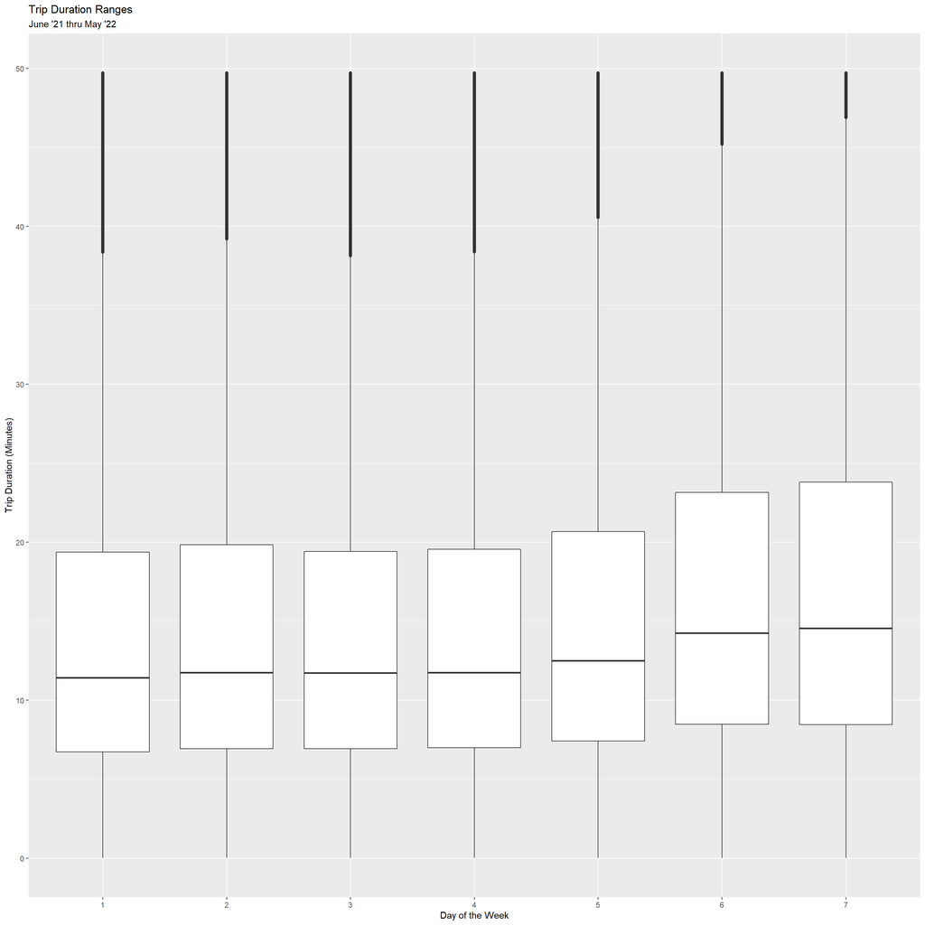

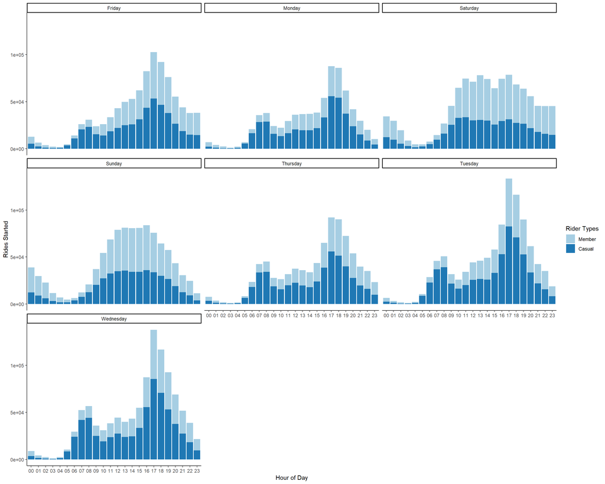